# My Investment is Better Than Yours

Erik McDonald

June 19, 2018

```r
me <- c("FSLR", "TSLA", "NFLX") %>%
  tq_get(get  = "stock.prices",
         from = "2017-10-01") %>%
  group_by(symbol)


frnd <- c("F", "GM", "CLD") %>%
  tq_get(get  = "stock.prices",
         from = "2017-10-01") %>%
  group_by(symbol)
```

## The Bet

Given the new economic outlook in Trump’s America, my friend and I have undertaken a bet. I believe that future is in technology, businesses that are innovative in bringing about new developments in tech will perform best. My friend believes that President Trump will make America great again and forsees the return of prosper in American blue collar jobs, he strongly believes that the best investment over the next year will be in coal, manufacturing, and autos.

My portfolio will consist of Netflix - NFLX, First Solar - FLSR, and Tesla TSLA.

My friend will buy General Motors - GM, Ford - F, and a coal company - CLD.

## Data Wrangling

```r
bet <- rbind(me, frnd)

bet <- bet %>%
  mutate(port = ifelse(grepl("FSLR", symbol),"mine",
                       ifelse(grepl("TSLA", symbol),"mine",
                              ifelse(grepl("NFLX", symbol),"mine", "his"))))


mywts_map <- tibble(
  symbols = c("FSLR", "TSLA", "NFLX"),
  weights = c(1/3, 1/3, 1/3)
)

frndwts_map <- tibble(
  symbols = c("F", "GM", "CLD"),
  weights = c(0.333, 0.333, 0.333)
)


me %>%
  tq_portfolio(assets_col  = symbol,
               returns_col = adjusted,
               weights     =  mywts_map,
               col_rename  = "Ra_using_wts_map")
```

```
## # A tibble: 179 x 2
##    date       Ra_using_wts_map
##    <date>                <dbl>
##  1 2017-10-02             189.
##  2 2017-10-03             270.
##  3 2017-10-04             315.
##  4 2017-10-05             335.
##  5 2017-10-06             345.
##  6 2017-10-09             337.
##  7 2017-10-10             352.
##  8 2017-10-11             352.
##  9 2017-10-12             355.
## 10 2017-10-13             355.
## # ... with 169 more rows
```

```r
#was having issues with the portfolio function so we will have to shelf this section of code for now, but we're off to a start

myside <- bet %>%
  group_by(port, date) %>%
  filter(port == "mine") %>%
  summarise(val = sum(adjusted)) %>%
  mutate(totval = val *1.8)

hisside <- bet %>%
  group_by(port, date) %>%
  filter(port == "his") %>%
  summarise(val = sum(adjusted)) %>%
  mutate(totval = val *18)

tot_bet <- rbind(myside, hisside)

#I instead built a portfolio variable referring to total value based off of the initial $1000 investment and equal weights
```

## Data Visualization

First we will compare overal portfolio performance.

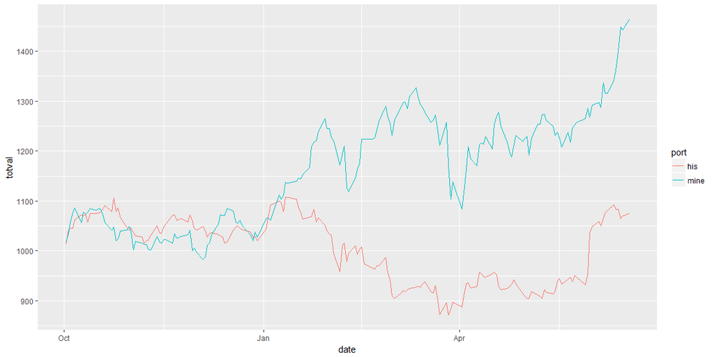

```r
tot_bet %>%
  ggplot(aes(x = date, y = totval, color = port)) +
  geom_line()
```

Now we will examine the performance of each stock from the portfolio

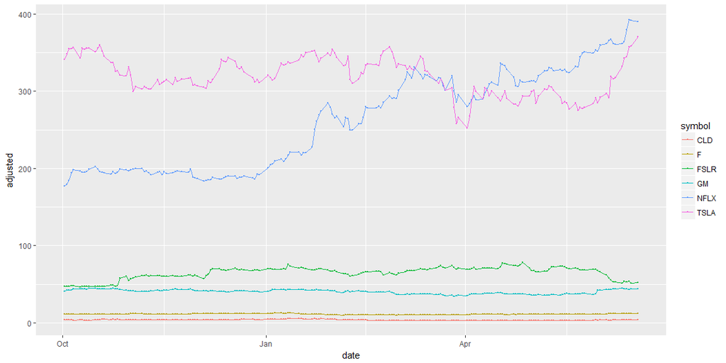

```r
bet %>%
  ggplot(aes(x = date, y = adjusted, color = symbol)) +
  geom_point(size = .1) +
  geom_line()
```

For more insight on stock patterns we will free the y axis on the stock visualization

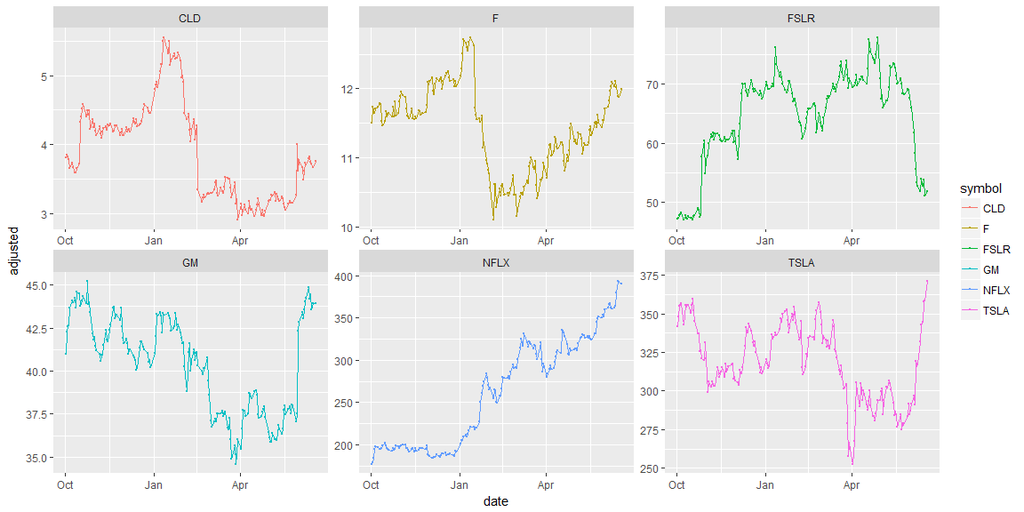

```r
bet %>%
  ggplot(aes(x = date, y = adjusted, color = symbol)) +
  geom_point(size = .1) +
  geom_line()+
  facet_wrap(~symbol, scales = "free")
```